Sesión 3

[figure not shown]

Instituto Tecnológico de Querétaro · TecNM · Maestría · Visión Artificial

# Sesión 3 Transformada de Hough y detección de esquinas (Harris)

**Dr. Víctor Alejandro González Huitrón**  
De los bordes a la **estructura geométrica**: votar por líneas y círculos, y localizar **keypoints** repetibles.

## ¿De dónde venimos y hacia dónde vamos?

En la sesión 2 obtuvimos **bordes**: dónde cambia la intensidad. Pero un borde es solo un conjunto de píxeles sueltos.

- La **Transformada de Hough** agrupa esos píxeles en **formas paramétricas** globales (líneas, círculos) aunque estén fragmentados u ocluidos.
- El **detector de Harris** encuentra **esquinas**: puntos localizables y repetibles que sirven de anclaje para seguimiento, calibración y correspondencia.

Ambos son **votación / análisis local acumulado**: en Hough cada píxel vota por las formas que podrían pasar por él; en Harris cada ventana acumula estadística de gradiente para decidir qué es.

P1 IoT médico — geometría como metadato compacto a transmitir.

P2 Mastografía — líneas/estructuras y calibración de anclas.

P3 ADAS — carriles (líneas) y keypoints para estéreo/odometría.

P4 YOLO en ARM — costo del acumulador y del detector de esquinas.

P5 Diabetes/DL — "votación" y "picos" como intuición para la fase pico en señales tabulares/temporales.

1

Parte 1

# Transformada de Hough

Detectar formas paramétricas mediante votación en un espacio de parámetros.

## El problema: de píxeles de borde a líneas

Tras detectar bordes tenemos una nube de puntos \((x_i,y_i)\). Queremos saber qué **líneas rectas** los explican, incluso si la línea está **rota** o tiene huecos.

- Probar todas las líneas posibles y contar cuántos puntos caen en cada una es **inviable** por fuerza bruta.
- **Idea de Hough:** invertir la pregunta. En vez de "¿qué puntos pertenecen a esta línea?", preguntamos "¿por qué líneas puede pasar **este** punto?".
- Cada punto **vota** por todas sus líneas candidatas. Las líneas reales reciben **muchos votos**.

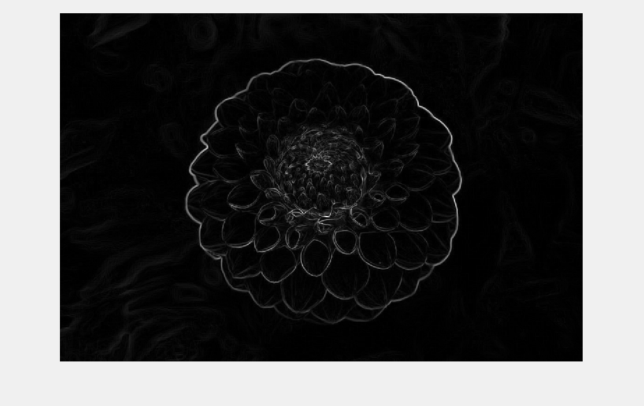

Mapa de bordes: puntos aislados que queremos agrupar en estructura.

## Dualidad punto ↔ recta (forma pendiente-ordenada)

Una recta en la imagen es \(y = m\,x + b\). Fijado un punto \((x_i,y_i)\), reordenamos viendo \((m,b)\) como las variables:

Recta en el espacio imagen\[ y_i = m\,x_i + b \]

La misma ecuación en el espacio de parámetros \((m,b)\)\[ b = -x_i\,m + y_i \]

- Un **punto** en la imagen es una **recta** en el espacio \((m,b)\).
- Dos puntos de la misma línea generan dos rectas en \((m,b)\) que **se cruzan** justo en el \((m,b)\) de la línea que comparten.
- **Colinealidad** ⇔ **intersección** de muchas rectas en un mismo punto de parámetros.

El problema de "buscar puntos alineados" se convierte en "buscar dónde se acumulan muchas intersecciones". Eso se resuelve **contando votos en una rejilla**.

**Problema práctico:** con \(y=mx+b\) la pendiente \(m\) tiende a \(\infty\) para líneas verticales. Necesitamos una parametrización acotada.

## Parametrización normal \((\rho,\theta)\)

Se describe la recta por la distancia \(\rho\) del origen a la recta y el ángulo \(\theta\) de su normal:

Ecuación normal de la recta\[ x\cos\theta + y\sin\theta = \rho \]

- \(\theta \in [0^\circ,180^\circ)\) y \(\rho \in [-\rho_{max},\rho_{max}]\): ambos **acotados** (adiós al \(m\to\infty\)).
- Fijado un punto \((x_i,y_i)\), al barrer \(\theta\) la ecuación traza una **sinusoide** en el plano \((\rho,\theta)\).
- Puntos colineales ⇒ sus sinusoides se **cruzan en un mismo \((\rho,\theta)\)**: los parámetros de la recta común.

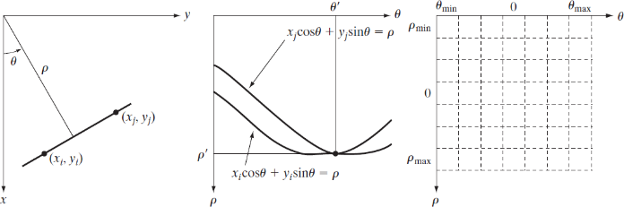

Izq.: \(\rho,\theta\) de una recta. Centro: cada punto → una sinusoide; su cruce da \((\rho',\theta')\). Der.: rejilla acumuladora.

## El acumulador: dónde se cuentan los votos

El plano \((\rho,\theta)\) se discretiza en una matriz \(A[\rho,\theta]\) de contadores, inicializada en cero. Cada píxel de borde **suma 1** a todas las celdas \((\rho,\theta)\) por las que pasa su sinusoide.

- Una recta real de la imagen produce un **máximo local** (pico) en el acumulador.
- La **altura del pico** ≈ número de píxeles que apoyan esa recta ⇒ permite descartar líneas débiles con un umbral.
- Robusto a **huecos y oclusiones**: los votos se acumulan aunque la línea esté fragmentada.

En la figura, los 5 puntos de una imagen generan 5 sinusoides; las intersecciones **A** y **B** son las dos rectas que conectan subconjuntos de esos puntos.

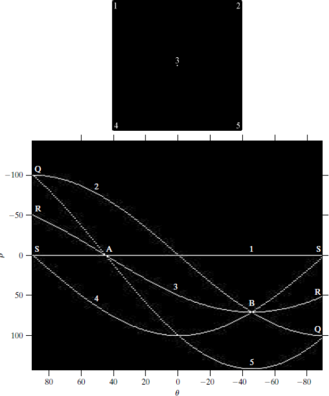

Acumulador \((\rho,\theta)\) para 5 puntos; A y B marcan colinealidades.

## Algoritmo de Hough para líneas, paso a paso

1. **Bordes.** Obtener mapa binario de bordes (p. ej. Canny) sobre la imagen.
2. **Discretizar.** Definir resolución \(\Delta\theta\) (p. ej. 1°) y \(\Delta\rho\) (p. ej. 1 px); crear acumulador \(A[\rho,\theta]=0\).
3. **Votar.** Para cada píxel de borde \((x,y)\) y cada \(\theta\): calcular \(\rho=x\cos\theta+y\sin\theta\), redondear a la celda e incrementar \(A[\rho,\theta]\mathrel{+}=1\).
4. **Umbral.** Conservar celdas con \(A[\rho,\theta] \ge T\) (rectas con suficiente apoyo).
5. **Picos.** Buscar máximos locales (supresión de no-máximos) para separar rectas cercanas.
6. **Reconstruir.** Convertir cada \((\rho,\theta)\) ganador de nuevo a una recta en la imagen.

Voto de un píxel\[ \rho = x\cos\theta + y\sin\theta \quad\forall\,\theta \]

**Costo:** por cada píxel de borde se recorren \(N_\theta\) ángulos. Total \(\approx O(E\cdot N_\theta)\), con \(E\) = número de píxeles de borde. La memoria es el tamaño del acumulador \(N_\rho \times N_\theta\).

Compromiso de resolución: celdas finas ⇒ picos nítidos pero votos dispersos y más ruido; celdas gruesas ⇒ picos robustos pero rectas imprecisas.

## Pipeline completo sobre una imagen real

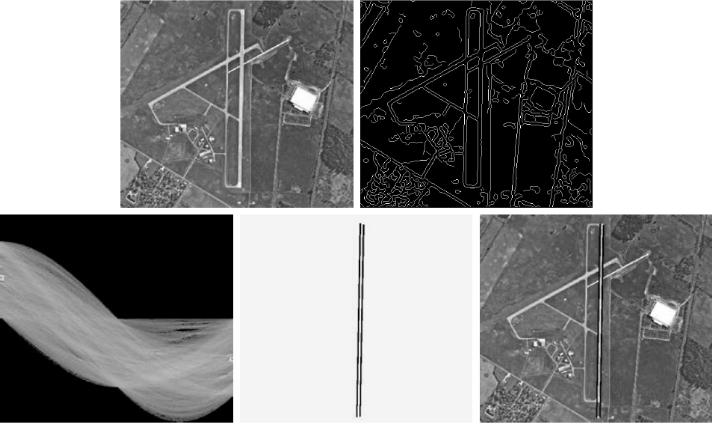

Imagen aérea → bordes (Canny) → acumulador de Hough → selección de pico → recta detectada reproyectada.

## Hough para círculos

Un círculo se parametriza por centro \((a,b)\) y radio \(r\):

Ecuación del círculo\[ (x-a)^2 + (y-b)^2 = r^2 \]

- El espacio de parámetros es ahora **3D**: \((a,b,r)\). Cada píxel de borde vota por un **cono** de posibles \((a,b,r)\).
- Si el **radio es conocido**, se fija \(r\) y cada píxel vota por un **círculo** de centros posibles en el plano \((a,b)\).
- **Truco del gradiente:** usar la **dirección del borde** para votar solo a lo largo de la normal reduce enormemente los votos y el costo.

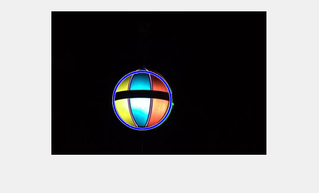

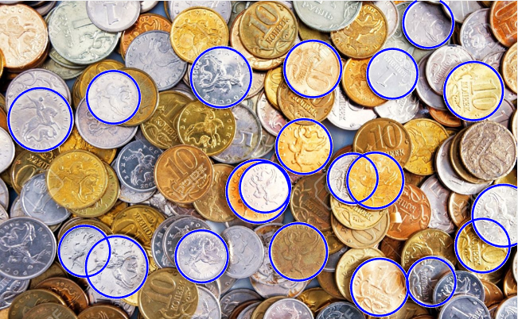

Detección de círculos por Hough: objeto único y múltiples monedas.

## Hough: fortalezas, límites y variantes

### Fortalezas

Tolera huecos y oclusión parcial; robusto a ruido moderado; detecta múltiples instancias a la vez; generaliza a cualquier forma paramétrica.

### Límites

El costo y la memoria explotan con el número de parámetros (líneas 2D → círculos 3D → elipses 5D). Sensible a la resolución de las celdas.

### Variantes

Hough probabilística (vota un subconjunto de píxeles); Hough con gradiente para círculos; **Generalized Hough Transform** para formas arbitrarias vía tabla-R.

### Puente a DL

La idea de **acumular evidencia y buscar picos** reaparece en mapas de calor de keypoints (*heatmaps*) y en capas tipo *voting* de detección moderna.

2

Parte 2

# Detección de esquinas: Harris

Encontrar keypoints repetibles analizando cómo cambia la intensidad al mover una ventana.

## ¿Por qué esquinas? La intuición de la ventana

Deslizamos una pequeña ventana sobre la imagen y observamos cuánto cambia el contenido:

- **Región plana:** al mover la ventana en cualquier dirección, casi nada cambia. No localizable.
- **Borde:** el contenido cambia al cruzar el borde, pero **no** cambia al deslizar **a lo largo** del borde. Ambiguo en una dirección.
- **Esquina:** el contenido cambia **mucho en todas las direcciones**. Es única y localizable ⇒ buen keypoint.

Harris convierte esta intuición en un cálculo por píxel **barato**, usando solo los gradientes que ya calculamos en la sesión 2.

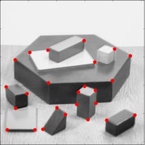

Esquinas (keypoints) detectadas sobre objetos poliédricos.

## La función de cambio \(E(u,v)\)

Medimos la **diferencia de intensidad** al desplazar la ventana un vector \((u,v)\), sumando el cuadrado del cambio sobre la ventana:

Cambio de intensidad para el desplazamiento \((u,v)\)\[ E(u,v)=\sum_{x,y} w(x,y)\,\big[\,I(x+u,\,y+v)-I(x,y)\,\big]^2 \]

- \(w(x,y)\): **función de ventana** (caja o gaussiana) que pondera y da peso a los píxeles centrales.
- Buscamos píxeles donde \(E(u,v)\) sea **grande para todo \((u,v)\)** ⇒ esquina.

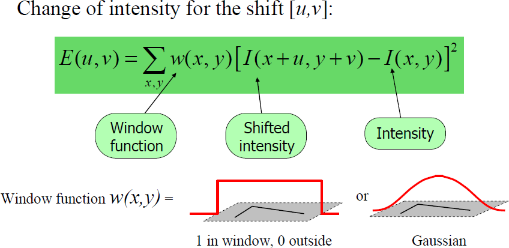

Componentes de \(E(u,v)\): ventana, intensidad desplazada e intensidad.

## Aproximación de Taylor: aparece la matriz \(M\)

Para desplazamientos pequeños, aproximamos por Taylor de primer orden \(I(x+u,y+v)\approx I + I_x u + I_y v\), con \(I_x,I_y\) los gradientes. Sustituyendo en \(E\):

Forma cuadrática\[ E(u,v)\;\approx\;\begin{bmatrix}u & v\end{bmatrix}\,M\,\begin{bmatrix}u\\ v\end{bmatrix} \]

Matriz de estructura (2×2)\[ M=\sum_{x,y} w(x,y)\begin{bmatrix} I_x^2 & I_x I_y\\ I_x I_y & I_y^2 \end{bmatrix} \]

- \(M\) resume la **distribución local del gradiente** alrededor del píxel.
- Toda la información de "cómo cambia la ventana en cada dirección" está en \(M\).

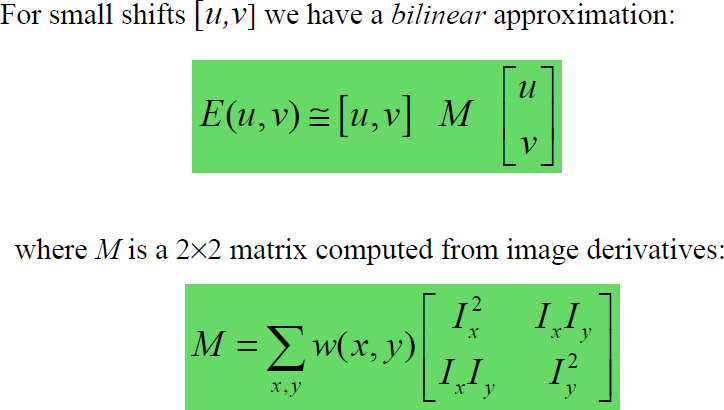

De la aproximación bilineal a la matriz \(M\) de derivadas.

## Eigenvalores de \(M\): la elipse de cambio

Los **eigenvalores** \(\lambda_1,\lambda_2\) de \(M\) miden cuánto cambia \(E\) en las dos direcciones principales. La curva \(E=\text{const}\) es una **elipse** cuyos ejes \(\propto \lambda^{-1/2}\).

- \(\lambda\) **grande** ⇒ cambio rápido en esa dirección (eje corto de la elipse).
- El **par** \((\lambda_1,\lambda_2)\) clasifica la vecindad sin ambigüedad.

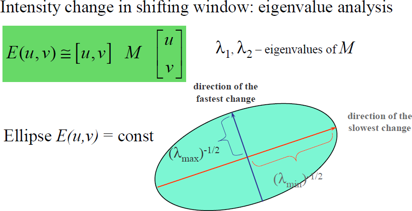

Elipse \(E(u,v)=\)const y direcciones de cambio rápido/lento.

## Clasificación por \((\lambda_1,\lambda_2)\)

- **Plano:** \(\lambda_1\) y \(\lambda_2\) **pequeños**. \(E\) casi constante en toda dirección.
- **Borde:** uno grande y otro pequeño (\(\lambda_1 \gg \lambda_2\) o viceversa). Cambio fuerte en una sola dirección.
- **Esquina:** **ambos grandes** y de magnitud comparable (\(\lambda_1 \sim \lambda_2\)). \(E\) crece en todas direcciones.

Calcular eigenvalores por píxel es costoso. Harris propone un **score \(R\)** equivalente que evita la descomposición explícita.

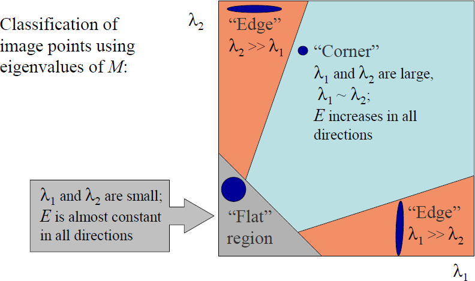

Regiones en el plano \((\lambda_1,\lambda_2)\): plano, borde y esquina.

## El score de respuesta \(R\)

Harris usa el determinante y la traza de \(M\), que se relacionan con los eigenvalores sin calcularlos:

Respuesta de esquina\[ R=\det(M)-k\,\big(\operatorname{tr}(M)\big)^2 \]

Con\[ \det(M)=\lambda_1\lambda_2,\qquad \operatorname{tr}(M)=\lambda_1+\lambda_2 \]

- **\(R\) grande y positivo** ⇒ esquina (ambos \(\lambda\) grandes).
- **\(R<0\)** ⇒ borde (un \(\lambda\) domina).
- **\(|R|\) pequeño** ⇒ región plana.
- \(k\) es una constante empírica, típicamente \(k=0.04\)–\(0.06\).

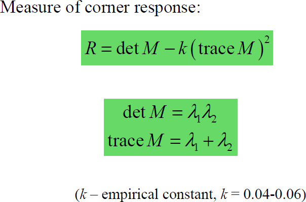

\(R=\det M - k\,(\operatorname{tr}M)^2\); \(k\) empírica ≈ 0.04–0.06.

## Algoritmo de Harris, paso a paso

1. **Gradientes.** Calcular \(I_x, I_y\) (p. ej. con Sobel).
2. **Productos.** Formar \(I_x^2,\; I_y^2,\; I_xI_y\) en cada píxel.
3. **Suavizar / ventana.** Convolucionar cada producto con \(w\) (gaussiana) ⇒ entradas de \(M\) por píxel.
4. **Respuesta.** Calcular \(R=\det M - k\,(\operatorname{tr}M)^2\) en cada píxel.
5. **Umbral.** Conservar \(R>T\).
6. **NMS.** Supresión de no-máximos para quedarse con un punto por esquina.

**Propiedades:** Harris es **invariante a rotación** (los eigenvalores no dependen de la orientación) y a cambios **aditivos** de brillo. **No** es invariante a **escala**: una esquina grande puede verse como borde con ventana pequeña.

La falta de invariancia a escala motivó detectores multiescala (Harris-Laplace) y descriptores como SIFT/ORB, que son la antesala de los keypoints aprendidos por CNN.

## Síntesis de la sesión

### Hough — idea

Cada píxel de borde vota en un espacio de parámetros; los picos son las formas presentes. Robusto a huecos y oclusión.

### Hough — ecuación

\(x\cos\theta+y\sin\theta=\rho\) para líneas; \((x-a)^2+(y-b)^2=r^2\) para círculos.

### Harris — idea

Una esquina cambia \(E(u,v)\) en todas direcciones. La matriz \(M\) de gradientes lo captura por píxel.

### Harris — ecuación

\(R=\det M - k\,(\operatorname{tr}M)^2\), con \(\det M=\lambda_1\lambda_2\) y \(\operatorname{tr}M=\lambda_1+\lambda_2\).

Ambos métodos **acumulan evidencia local** para tomar una decisión global — la misma lógica que, escalada y aprendida, sostiene la detección con redes profundas.

3

Trabajo fuera de clase

# Actividades por perfil

Cada quien ancla Hough y Harris a su dominio de tesis. Se revisa la siguiente sesión con rúbrica común.

P1 · IoT médico P2 · Mastografía P3 · ADAS P4 · YOLO en ARM P5 · Diabetes / DL tabular

## Resumen de entregables por perfil

P1 · IoT médico Detectar la **rejilla/tiras** de un formato médico con Hough de líneas; transmitir solo los **parámetros \((\rho,\theta)\)** como metadato geométrico compacto vs. la imagen.

P2 · Mastografía Usar **Hough de círculos** para localizar nódulos/marcadores aproximadamente circulares y **Harris** como anclas de registro entre vistas.

P3 · ADAS Detección de **líneas de carril** con Hough bajo distintas condiciones y **keypoints Harris** repetibles para correspondencia estéreo.

P4 · YOLO en ARM Implementar el **acumulador de Hough** y el **score de Harris**, midiendo su costo en ARM frente a alternativas.

P5 · Diabetes / DL Trasladar la idea de **votación y picos** a series/tablas de indicadores: detección de picos y "estructura" como preludio a CNN/LSTM.

El detalle completo de cada actividad y la rúbrica están en el documento de actividades de la Sesión 3.

Sesión 3 · Visión Artificial

# ¿Preguntas?

Siguiente paso: descriptores locales (SIFT/ORB) y correspondencia — el puente hacia los keypoints aprendidos.